# Prediction the CEFR Level of English Movies

## Project Description

Watching movies in the original language is a popular and effective method to get pumped when learning foreign languages. It is important to choose a film that suits the student's level of difficulty, so that the student understands 50-70% of the dialogues.

CEFR stands for Common European Framework of Reference. It is the most trusted language ability measurement system in the world. It ranks students as beginner, intermediate and advanced. CEFR is also used to rank the difficulty of teaching materials like reading and listening.

Organisations like Cambridge, Oxford, British Council, etc. rely on CEFR to structure their teaching content.

[figure not shown]

## Goals

The idea of this project is to develop an ML solution to automatically determine the difficulty level of English-language movies. We will develop a classification for these films based on their difficulty level.

## Data

### Key Data

- [Full list of movies and scores](https://www.notion.so/Films-according-to-CEFR-a702061c0fe341ec9fcc98c4eea341e3)
- [Subtitle folder](https://disk.yandex.ru/d/CkmiSRnKba76sA)

### Supplementary Data

- Similar work has been done here:
  > - [The Best Movies to Learn a Foreign Language According to Data Science](https://towardsdatascience.com/the-best-movies-to-learn-english-according-to-data-science-2dccb4b3ee23)
  > - [Attempting to Predict the CEFR Level of English Texts](https://amontgomerie.github.io/2021/03/14/cefr-level-prediction.html)
  > - [A New Resource to Measure Text Difficulty](https://aclanthology.org/2020.lrec-1.890.pdf)
- There are services for analyzing text complexity:
  > - [Text Inspector](https://languageresearch.cambridge.org/wordlists/text-inspector)
  > - [CEFR Checker](https://www.cathoven.com/en/cefr-checker/)
  > - [Oxford 3000 and 5000](https://www.oxfordlearnersdictionaries.com/wordlists/oxford3000-5000)
  > - [Data Augmentation in NLP](https://neptune.ai/blog/data-augmentation-nlp)

# Loading and Preprocessing Data

CEFR dictionaries with difficulty levels are stored in text files.

- Files have been opened and read.
- The dataset is built.

```
                                                    text
level
A1     [about, above, across, action, activity, actor...
A2     [able, abroad, accept, accident, according, ac...
B1     [academic, access, accommodation, account, ach...
B2     [absolute, academic, acceptable, accompany, ac...
C1     [abortion, absence, absent, absurd, abundance,...
```

Subtitles for movies are in separate files.

- Files with subtitles have been opened and read.
- The dataset is assembled.

| Movie | text |
| --- | --- |
| 10_Cloverfield_lane(2016) | <font color="#ffff80"><b>Fixed & Synced by boz... |
| 10_things_I_hate_about_you(1999) | Hey! I'll be right with you. So, Cameron. Here... |
| A_knights_tale(2001) | Resync: Xenzai[NEF]\nRETAIL Should we help him... |
| A_star_is_born(2018) | - <i><font color="#ffffff"> Synced and correct... |
| Aladdin(1992) | <i>Oh, I come from a land\nFrom a faraway plac... |

Subtitles are messy and contain a lot of service information.

- Removed tags, punctuation, capital letters, stop words (prepositions and pronouns).
- The text is divided into **tokens**, i.e. we received **a list of single words** included in the subtitles for each movie.

| Movie | text |
| --- | --- |
| 10_Cloverfield_lane(2016) | [fixed, synced, bozxphd, enjoy, the, flick, cl... |
| 10_things_I_hate_about_you(1999) | [hey, i'll, right, so, cameron, here, go, nine... |
| A_knights_tale(2001) | [resync, xenzai, nef, retail, should, help, he... |
| A_star_is_born(2018) | [synced, corrected, mrcjnthn, get, black, eyes... |
| Aladdin(1992) | [oh, i, come, land, from, faraway, place, wher... |

There are few features. In order to **enrich the dataset**, we will combine the table with the CEFR dictionary and the dataframe with movies.

- Сount the number of words in movies. (Column 'total')
- The number of words of each level in the movies. (Columns 'A1','A2','B1','B2','C1',)
- The ratio of the total number of words to the number of words from the dictionary. (Column 'ratio_A1_words',...)
- The ratio of words from the dictionary to the number of them in movies.(Column 'ratio_A1_level_A1 ',...)
- The year of the film's release.

|  | Movie | A1 | A2 | B1 | B2 | C1 | total | level_words | ratio_A1_words | ratio_A2_words | ratio_B1_words | ratio_B2_words | ratio_C1_words | ratio_A1_words_level | ratio_A2_words_level | ratio_B1_words_level | ratio_B2_words_level | ratio_C1_words_level | year |
| --- | --- | --- | --- | --- | --- | --- | --- | --- | --- | --- | --- | --- | --- | --- | --- | --- | --- | --- | --- |
| 1 | 10 Cloverfield lane | 1384 | 378 | 279 | 210 | 83 | 3386 | 2334.0 | 40.874188 | 11.163615 | 8.239811 | 6.202008 | 2.45127 | 59.297344 | 16.195373 | 11.953728 | 8.997429 | 3.556127 | 2016 |
| 2 | 10 things I hate about you | 2291 | 570 | 428 | 327 | 159 | 5054 | 3775.0 | 45.330431 | 11.278195 | 8.46854 | 6.470123 | 3.146023 | 60.688742 | 15.099338 | 11.337748 | 8.662252 | 4.211921 | 1999 |
| 3 | A knights tale | 1737 | 579 | 338 | 319 | 157 | 4574 | 3130.0 | 37.975514 | 12.658505 | 7.389593 | 6.974202 | 3.432444 | 55.495208 | 18.498403 | 10.798722 | 10.191693 | 5.015974 | 2001 |
| 4 | A star is born | 3656 | 836 | 534 | 449 | 200 | 7807 | 5675.0 | 46.829768 | 10.708339 | 6.840015 | 5.751249 | 2.561804 | 64.422907 | 14.731278 | 9.409692 | 7.911894 | 3.524229 | 2018 |
| 5 | Aladdin | 2061 | 690 | 501 | 392 | 141 | 5457 | 3785.0 | 37.768004 | 12.64431 | 9.180869 | 7.183434 | 2.583837 | 54.451783 | 18.229855 | 13.23646 | 10.356671 | 3.725231 | 1992 |

A table with a target variable.

The CEFR level is set by a linguistic expert.

The criteria for assessing the assignment of the difficulty level are unknown.

|  | Movie | Level | Subtitles | Kinopoisk |
| --- | --- | --- | --- | --- |
| 0 | 10 Cloverfield lane | B1 | Yes | NaN |
| 1 | 10 things I hate about you | B1 | Yes | No subs |
| 2 | A knights tale | B2 | Yes | Everything |
| 3 | A star is born | B2 | Yes | Nope |
| 4 | Aladdin | A2/A2+ | Yes | Everything |
| ... | ... | ... | ... | ... |
| 83 | Twilight | A2/A2+ | Yes | No subs,Paid |
| 84 | Up | A2/A2+ | Yes | Everything |
| 85 | Venom | B2 | Yes | Everything |
| 86 | Warm bodies | B1 | Yes | Everything,Paid |
| 87 | We are the Millers | B1 | Yes | Nope |

88 rows × 4 columns

Merged the dataset with the movies and the target variable into one data frame.

```
<class 'pandas.core.frame.DataFrame'>
Int64Index: 86 entries, 0 to 87
Data columns (total 20 columns):
 #   Column                Non-Null Count  Dtype
---  ------                --------------  -----
 0   Movie                 86 non-null     object
 1   Level                 86 non-null     object
 2   A1                    86 non-null     float64
 3   A2                    86 non-null     float64
 4   B1                    86 non-null     float64
 5   B2                    86 non-null     float64
 6   C1                    86 non-null     float64
 7   total                 86 non-null     float64
 8   level_words           86 non-null     float64
 9   ratio_A1_words        86 non-null     float64
 10  ratio_A2_words        86 non-null     float64
 11  ratio_B1_words        86 non-null     float64
 12  ratio_B2_words        86 non-null     float64
 13  ratio_C1_words        86 non-null     float64
 14  ratio_A1_words_level  86 non-null     float64
 15  ratio_A2_words_level  86 non-null     float64
 16  ratio_B1_words_level  86 non-null     float64
 17  ratio_B2_words_level  86 non-null     float64
 18  ratio_C1_words_level  86 non-null     float64
 19  year                  86 non-null     float64
dtypes: float64(18), object(2)
memory usage: 14.1+ KB
```

### Conclusion

- 86 rows containing movie subtitles have been gotten.
- The dataset contains text and numeric data.
- The text data is cleaned and tokenized.
- The numerical data contains the total number of words, the number of words by levels, and other quantitative features.
- All data types in data sets are represented in the corresponding data type.

## Target variable

There is a classification problem with five classes.

The data is unbalanced.

The dataset contains only 86 observations. This can significantly affect the accuracy of the prediction.

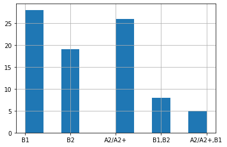

```
B1           28
A2/A2+       26
B2           19
B1,B2         8
A2/A2+,B1     5
Name: Level, dtype: int64
```

# Features Analysis

The distribution of words from the CEFR levels is close to normal.

That is, some words are quite rare, and the rest are quite common in all movies.

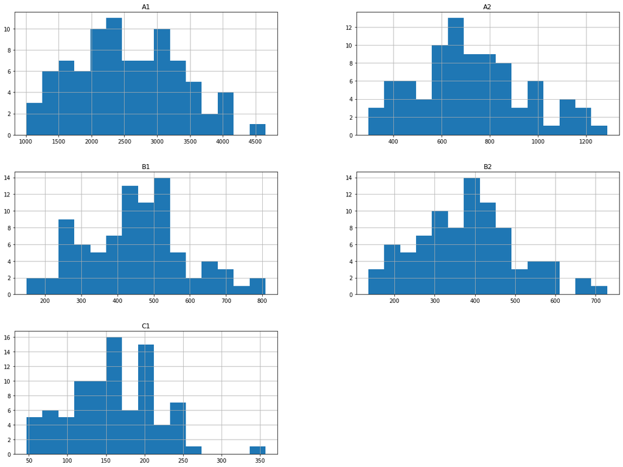

A1 level words dominate in all movies.

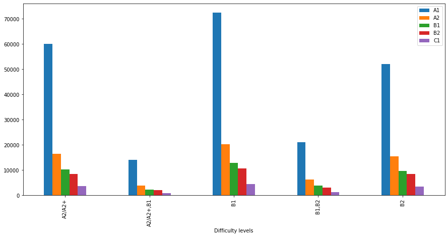

The number of words in each movie also has a normal distribution, i.e. movies have a close to average number of words.

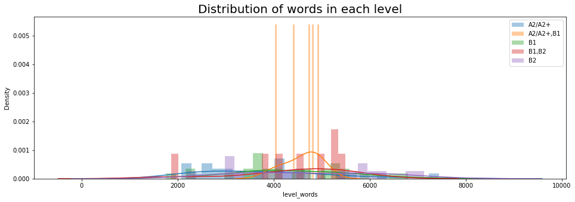

The number of words in films with a known level of difficulty is also close to the average.

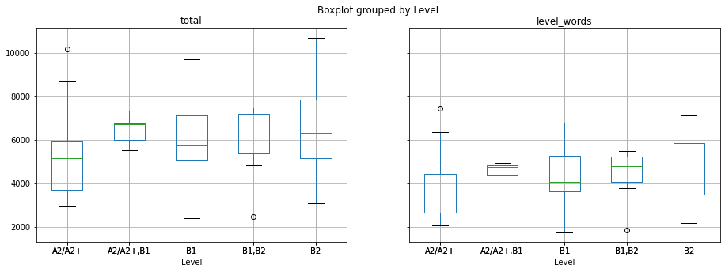

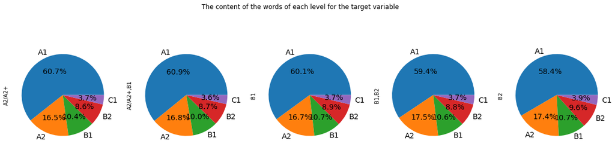

There is a noticeable linear relationship between the levels of complexity in movies.

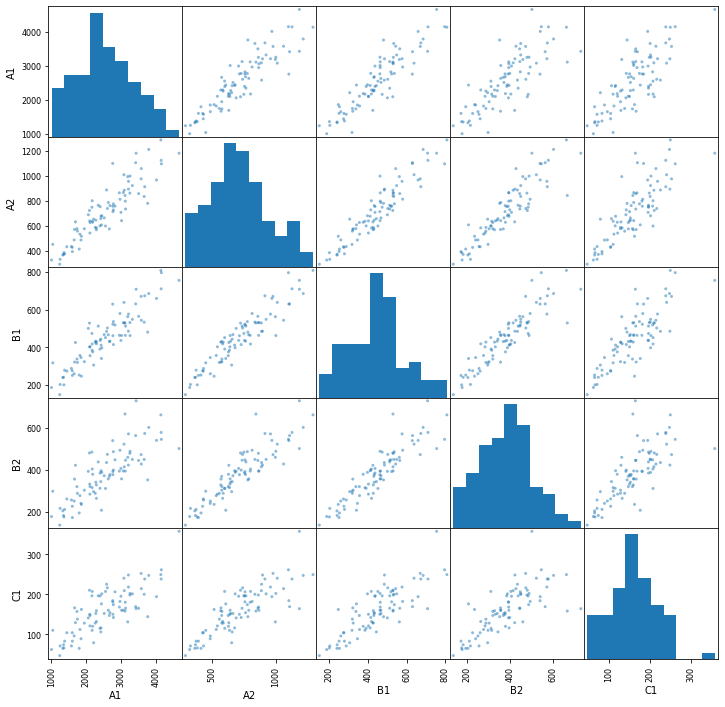

There is a good correlation between the levels of difficulty in movies.

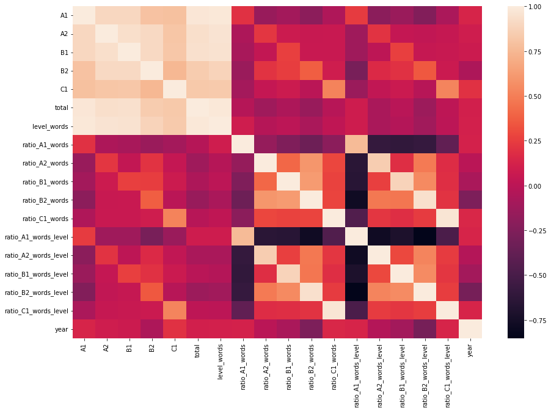

## Conclusion

- The graphs show that all subtitles are dominated by A1-level words. Since the texts consist mainly of dialogues, this makes sense.
- Since there is a correlation between the number of words of each level, we will train numerical and text data separately.

# Prediction by numerical features

Text features have been removed from the dataset in order to train only on numerical features.

## Feature Engineering

Split the data into training and test data.

```
((64, 18), (22, 18))
```

## Scaling

The features have different scales. So that the model does not overfit we should scale data.

## Machine learning

We have a multi classification problem, so we will choose:

- **Logistic Regression.** This is a classic classification algorithm. It has average accuracy, learns quickly, predicts linear dependence well, effective on small amounts of data.
- **Random Forest Classifier.** This algorithm is suitable for most machine learning tasks. It has excellent accuracy, average training time and a small number of hyperparameters.
- **XGBoost Classifier.** This algorithm uses weak linear algorithms and decision trees. It takes a long time to learn and has a large number of hyperparameters, but it has excellent accuracy.

### Logistic Regression

### Random Forest Classifier

Found the best hyperparameters for the model.

```
Fitting 3 folds for each of 48 candidates, totalling 144 fits
```

```
{'max_depth': 50,
 'max_features': 5,
 'min_samples_leaf': 3,
 'min_samples_split': 8,
 'n_estimators': 100}
```

### XGBoost Classifier

Found the best hyperparameters for the model.

```
{'learning_rate': 0.1,
 'max_depth': 5,
 'n_estimators': 50,
 'objective': 'multi:softmax',
 'verbose': False}
```

## Accuracy

**Accuracy** is the percentage of documents for which the classifier made the correct prediction.

$Accuracy = \frac{P}{N}$

where $P$ is the number of documents for which the classifier made the correct prediction, and $N$ is the size of the training sample.

The **F1** metric is a harmonic mean between precision and recall.

$F1= 2\times \frac{Precision \times Recall}{Precision + Recall}$

The **precision** of the system within a class is the proportion of documents actually belonging to this class relative to all documents that the system has assigned to this class.

$Precision = \frac{TP}{TP + FP}$

The **recall** of the system is the proportion of documents found by the classifier belonging to the class relative to all documents of this class in the test sample.

$Recall = \frac{TP}{TP + FN}$

where,

$TP$ — true-positive prediction

$TN$ — true-negative prediction

$FP$ — false-positive prediction

$FN$ — false-negative prediction

```
Names of classes:  ['A2/A2+', 'A2/A2+,B1', 'B1', 'B1,B2', 'B2']
```

|  | error_type | Logistic Regression | Random Forest Classifier | XGBoost Classifier |
| --- | --- | --- | --- | --- |
| 0 | Accuracy | 0.318182 | 0.318182 | 0.454545 |
| 1 | F1 | [0.28571428571428575, 0.2857142857142857, 0.0,... | [0.39999999999999997, 0.1818181818181818, 0.0,... | [0.5333333333333333, 0.0, 0.20000000000000004,... |

Prediction accuracy is no more than 50%.

## Important Features

Features that each model highlighted as important.

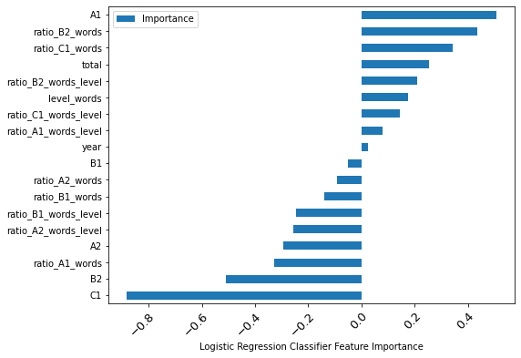

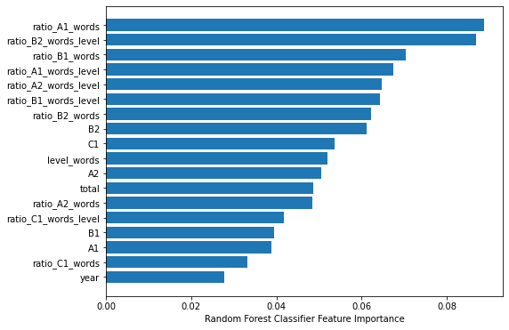

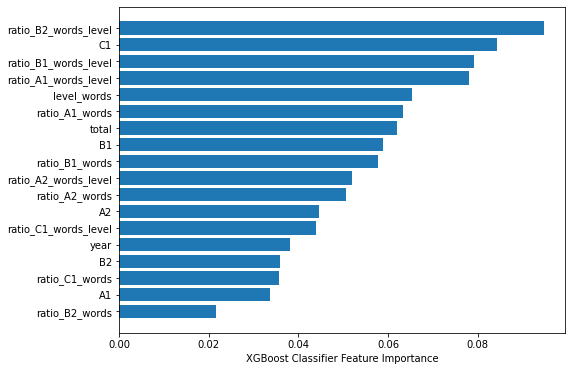

There are no clearly defined features common to all selected models.

Each model has chosen its own set of features for training.

Therefore, it cannot be said that there is a good linear relationship between subtitles and the CEFR dictionary.

## Conclusion

All the models that we chose to train the dataset showed poor accuracy and F1 score.

If I continue to work with numerical features, I would try:

- Extract parts of speech for CEFR levels.
- Calculate the number of parts of speech in subtitles.
- Сalculate the average number of words in sentences.
- Collect more subtitles.

# Prediction by text features

Our goal is to predict the complexity of the level of English-language movies.

So the main features for our model should be words.

## Bag of Words

The text of each movie consists of a set of words.

The number of different words in the text should record in a vector.

This approach is called a “bag of words” (BoW), because we lose all information about the relative position of words inside the text.

But even though the loss of this information, texts can be compared with words in the CEFR dictionary.

|  | movie | target_var | able | abortion | abroad | absence | absent | absolute | abstract | absurd | ... | worthy | wrist | written | wrong | yard | yell | yield | young | youngster | youth |
| --- | --- | --- | --- | --- | --- | --- | --- | --- | --- | --- | --- | --- | --- | --- | --- | --- | --- | --- | --- | --- | --- |
| 0 | 10 Cloverfield lane | B1 | 3.0 | 0.0 | 0.0 | 0.0 | 0.0 | 0.0 | 0.0 | 0.0 | ... | 0.0 | 0.0 | 0.0 | 2.0 | 0.0 | 0.0 | 0.0 | 1.0 | 0.0 | 0.0 |
| 1 | 10 things I hate about you | B1 | 1.0 | 0.0 | 0.0 | 0.0 | 0.0 | 0.0 | 0.0 | 0.0 | ... | 1.0 | 0.0 | 1.0 | 7.0 | 0.0 | 0.0 | 0.0 | 1.0 | 0.0 | 0.0 |
| 2 | A knights tale | B2 | 1.0 | 0.0 | 0.0 | 2.0 | 0.0 | 0.0 | 0.0 | 0.0 | ... | 2.0 | 0.0 | 0.0 | 4.0 | 0.0 | 0.0 | 0.0 | 0.0 | 0.0 | 0.0 |
| 3 | A star is born | B2 | 3.0 | 0.0 | 0.0 | 0.0 | 0.0 | 0.0 | 0.0 | 0.0 | ... | 0.0 | 0.0 | 0.0 | 7.0 | 0.0 | 0.0 | 0.0 | 0.0 | 0.0 | 0.0 |
| 4 | Aladdin | A2/A2+ | 1.0 | 0.0 | 0.0 | 0.0 | 0.0 | 1.0 | 0.0 | 0.0 | ... | 4.0 | 0.0 | 1.0 | 6.0 | 0.0 | 0.0 | 0.0 | 3.0 | 0.0 | 2.0 |
| ... | ... | ... | ... | ... | ... | ... | ... | ... | ... | ... | ... | ... | ... | ... | ... | ... | ... | ... | ... | ... | ... |
| 83 | Twilight | A2/A2+ | 2.0 | 0.0 | 0.0 | 0.0 | 0.0 | 0.0 | 0.0 | 0.0 | ... | 0.0 | 0.0 | 0.0 | 7.0 | 0.0 | 0.0 | 0.0 | 0.0 | 0.0 | 0.0 |
| 84 | Up | A2/A2+ | 0.0 | 0.0 | 0.0 | 0.0 | 0.0 | 0.0 | 0.0 | 0.0 | ... | 0.0 | 0.0 | 0.0 | 3.0 | 2.0 | 0.0 | 0.0 | 0.0 | 0.0 | 0.0 |
| 85 | Venom | B2 | 3.0 | 0.0 | 0.0 | 0.0 | 0.0 | 0.0 | 0.0 | 0.0 | ... | 1.0 | 0.0 | 1.0 | 3.0 | 0.0 | 0.0 | 0.0 | 1.0 | 0.0 | 0.0 |
| 86 | Warm bodies | B1 | 0.0 | 0.0 | 0.0 | 0.0 | 0.0 | 0.0 | 0.0 | 0.0 | ... | 0.0 | 0.0 | 0.0 | 4.0 | 0.0 | 0.0 | 0.0 | 1.0 | 0.0 | 0.0 |
| 87 | We are the Millers | B1 | 1.0 | 0.0 | 0.0 | 0.0 | 0.0 | 0.0 | 0.0 | 0.0 | ... | 0.0 | 0.0 | 0.0 | 14.0 | 0.0 | 0.0 | 0.0 | 3.0 | 0.0 | 0.0 |

86 rows × 4042 columns

The number of words from the CEFR dictionary that each movie has is obtained.

### Feature Engineering

The size of the train and test data.

```
((64, 4039), (22, 4039))
```

## Machine learning

The same machine learning models are trained.

### Logistic Regression

### Random Forest Classifier

### XGBoost Classifier

## Accuracy

```
Names of classes:  ['A2/A2+', 'A2/A2+,B1', 'B1', 'B1,B2', 'B2']
```

|  | error_type | Logistic Regression | Random Forest Classifier | XGBoost Classifier |
| --- | --- | --- | --- | --- |
| 0 | Accuracy | 0.409091 | 0.318182 | 0.363636 |
| 1 | F1 | [0.5263157894736842, 0.0, 0.4615384615384615, ... | [0.42857142857142855, 0.0, 0.4, 0.0] | [0.4444444444444444, 0.0, 0.4615384615384615, ... |

Prediction accuracy is no more than 50%.

The F1 metric gave a better prediction for classes A2/A2+ and B1, because the dataset has more data for these classes.

## Conclusion

All the models that we chose to train the dataset showed poor accuracy and F1 score.

If I continue to work with text characteristics, I would try:

- use embedding to represent the semantic closeness of words
- use pre-trained models, for example BERT
- unsupervised learning, where the model itself must understand the dependence, pattern and grouping of data.

The results depend on the corpus of the text we are working with, and we have a small one.

## Another Approach

To increase the size of the dataset, we will generate synthetic data.

In this task, the semantic aspect of the generated sentences does not matter to us. Therefore, a method based on the frequency of use of training corps bigrams is taken.

- A dictionary based on text classification has been created.
- The dictionary consists of grouped bigrams: the keys are individual words (tokens), the value is a list of words that follow them in a text corpus with their own frequency.
- 5 sentences of 15 words each are generated.

|  | Level | text |
| --- | --- | --- |
| 0 | 'B2' | seanathon, meter, jacket and blue i through, k... |
| 1 | 'B1' | operating, spaghetti, well and ended with, eli... |
| 2 | 'B1' | figure the i tired of silver tuna tonight, hyd... |
| 3 | 'B2' | unpresentable appearance, patriot, belts, shoo... |
| 4 | 'B1' | owned that anywhere i alive you last governmen... |

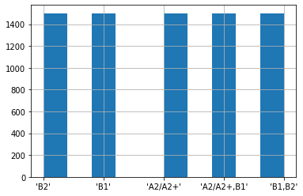

```
<class 'pandas.core.frame.DataFrame'>
RangeIndex: 7500 entries, 0 to 7499
Data columns (total 2 columns):
 #   Column  Non-Null Count  Dtype
---  ------  --------------  -----
 0   Level   7500 non-null   object
 1   text    7500 non-null   object
dtypes: object(2)
memory usage: 117.3+ KB
```

**The dataset has 7,500 rows.**

### Logistic Regression

### Random Forest Classifier

### XGBoost Classifier

## Accuracy

```
Names of classes:  ['A2/A2+', 'A2/A2+,B1', 'B1', 'B1,B2', 'B2']
```

|  | error_type | Logistic Regression | Random Forest Classifier | XGBoost Classifier |
| --- | --- | --- | --- | --- |
| 0 | Accuracy | 0.627733 | 0.642133 | 0.6496 |
| 1 | F1 | [0.5909090909090909, 0.644808743169399, 0.6509... | [0.6657018813314038, 0.6164383561643836, 0.681... | [0.6449864498644986, 0.6484375, 0.684856753069... |

```
              precision    recall  f1-score   support

    'A2/A2+'       0.60      0.58      0.59       382
 'A2/A2+,B1'       0.66      0.63      0.64       374
        'B1'       0.65      0.66      0.65       378
     'B1,B2'       0.61      0.65      0.63       371
        'B2'       0.62      0.62      0.62       370

    accuracy                           0.63      1875
   macro avg       0.63      0.63      0.63      1875
weighted avg       0.63      0.63      0.63      1875
```

The model with the addition of generated data gave the result of prediction accuracy much higher than previous models.

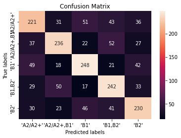

The confusion matrix shows the predictions of the model against the true. On the diagonal there are correct predictions. There are prediction errors above and below.

## Conclusion

Classifying a text with more than two classes is one of the most difficult problem in machine learning.

Raw data requires serious processing before training the model.

The size of the dataset and a strong imbalance in the classes have a very noticeable effect on the final accuracy of the prediction.

# Testing the Model

There are many sites on the Internet for learning English from movies.

Movies are already marked up by difficulty levels.

For prediction, the movie "Charlie and the Chocolate Factory (2005)" with difficulty level B1 is taken.

Movies by Levels

```
Counter({"'A2/A2+'": 42, "'B1,B2'": 5067, "'B2'": 3})
```

### Conclusion

The close relationship between the difficulty levels A2/A2+ **->** A2/A2+,B1 **->** B1 **->** B1,B2 **->** B2 in the training data affects the determination of the difficulty level.

Testing showed that for a movie with a difficulty level of B1, the model predicted more values of class **"B1,B2"**.

It accurately determined that this is not the A2 or B2 level, so we can develop this approach further to obtain more accurate forecasts.

# Conclusion

**Goal:** The goal of the project is to predict the level of complexity of an English-language movie by subtitles.

**Baseline Information:**

- Small data size
- Strong class imbalance
- Lack of criteria for determining the level of difficulty

**Approaches:**

1. Collect more data for training.
2. Use methods and linguistic approaches based on which experts determine the level of complexity of the text.
3. Implement pre-trained models to determine the complexity of subtitles by: semantic proximity of the meanings of texts, to find patterns and sequences of words and parts of speech in the text.

**Thank you for your interest!**